# 第 14 章 统计计算方法

## 14.1 非线性方程的求解

#### 14.1.0.1 二分法

**Method 14.1**. **（Bisection Method）**

设函数$f$在$[a,b]$上连续，且满足$f(a)f(b)<0$。为求解非线性方程$f(x)=0$，由引理 3.3可知，存在至少一个根$x^{\star}\in(a,b)$。二分法通过反复对区间进行二等分来逐步缩小根所在的区间：令：

$$\begin{equation*}
c=\frac{a+b}{2}
\end{equation*}$$

若$f(c)=0$，则$c$即为方程的解；否则根据符号判定准则，取满足：

$$\begin{equation*}
f(a)f(c)<0\quad\text{或}\quad f(c)f(b)<0
\end{equation*}$$

的子区间作为新的区间$[a,b]$，并重复上述过程。

经过$n$次迭代后，所得区间长度不超过$(b-a)/2^n$，任意迭代点$x_n$与真根$x^{\star}$的误差满足：

$$\begin{equation*}
|x_n-x^{\star}|\leqslant\frac{b-a}{2^n}
\end{equation*}$$

因此，可通过给定误差容许值$\varepsilon$，选取满足：

$$\begin{equation*}
\frac{b-a}{2^n}\leqslant\varepsilon
\end{equation*}$$

的最小整数$n$来控制计算精度。

#### 14.1.0.2 不动点迭代法

**Method 14.2**. **（Fixed-point Iteration Method）**

为求解非线性方程$f(x)=0$，可将其改写为等价的形式$x=T(x)$，若$T$是一个压缩映射，由定理 3.20可求得非线性方程的根。对于迭代次数问题，可用定理 3.20中的第二种误差估计公式来控制精度。

**Definition 14.1**. 设映射$T$有不动点$x^{\star}$。若存在$x^{\star}$的邻域$\bar{U}(x^{\star},\delta)$满足对任意的$x\in\bar{U}(x^{\star},\delta)$，序列$\{x_n=T^nx\}\to x^{\star}$，则称此时的迭代法局部收敛（local convergence）。

**Theorem 14.1**. 设映射$T$有不动点$x^{\star}$，$T'$在$x^{\star}$的某个邻域内连续，且$|T'x^{\star}|<1$，则此时的迭代法局部收敛。

*证明*. 由条件和性质 3.2.9(5)可知存在$x^{\star}$的邻域$U$和$L$，使得对任意的$x\in U$有$|T'x|\leqslant L<1$。根据定理 4.3可知对任意的$x'\in U$有：

$$\begin{equation*}
|Tx-Tx^{\star}|\leqslant L|x-x^{\star}|
\end{equation*}$$

即$T$在$x^{\star}$的某个闭邻域内是压缩映射，由定理 3.8、性质 3.2.6(1)和定理 3.20可知此时的迭代法局部收敛。 ◻

**Definition 14.2**. 设迭代过程$x_{n+1}=Tx_n$收敛于$T$的不动点$x^{\star}$。令$\varepsilon_n=x_n-x^{\star}$，若有：

$$\begin{equation*}
\lim_{n\to+\infty}\frac{\varepsilon_{n+1}}{\varepsilon_n^p}=C\in\mathbb{R}^{}\setminus\{0\}
\end{equation*}$$

则称该迭代过程是$p$阶收敛的。特别的，$p=1$且$|C|<1$时称为线性收敛（linear convergence），$p>1$时称为超线性收敛（superlinear convergence）。

**Theorem 14.2**. 设迭代过程$x_{n+1}=Tx_n$。若对于$p\in\mathbb{N}^+$，$T^{(p)}$在$T$的不动点$x^{\star}$的某个邻域内连续，并且有：

$$\begin{equation*}
T'x^{\star}=T''x^{\star}=\cdots=T^{(p-1)}x^{\star}=0,\;T^{(p)}x^{\star}\ne0
\end{equation*}$$

则该迭代过程在$x^{\star}$邻近是$p$阶收敛的。

*证明*. 由$T'x^{\star}=0$和定理 14.1可知该迭代过程是局部收敛的。根据可得：

$$\begin{equation*}
Tx_n=Tx^{\star}+\frac{T^{(p)}\xi_n}{p!}(x_n-x^{\star})^p,\quad\xi_n\text{在$x_n$与$x^{\star}$之间}
\end{equation*}$$

所以：

$$\begin{equation*}
\frac{Tx_n-x^{\star}}{(x_n-x^{\star})^p}=\frac{T^{(p)}\xi_n}{p!}
\end{equation*}$$

由$T^{(p)}$在$x^{\star}$某个邻域内的连续性和性质 3.2.9(8.c)(4.a)可得：

$$\begin{equation*}
\lim_{n\to+\infty}\frac{Tx_n-x^{\star}}{(x_n-x^{\star})^p}=\lim_{n\to+\infty}\frac{T^{(p)}\xi_n}{p!}=\frac{1}{p!}T^{(p)}\left(\lim_{n\to+\infty}\xi_n\right)=\frac{T^{(p)}x^{\star}}{p!}
\end{equation*}$$

◻

#### 14.1.0.3 牛顿法

**Method 14.3**. **（Newton Method）**

设$f$在根$x^{\star}$的某个邻域内是$C^2$类函数，且满足$f(x^{\star})=0,\;f'(x^{\star})\ne0$。为求解非线性方程$f(x)=0$，牛顿法对$f$在当前迭代点$x_n$处作一阶Taylor展开，得到：

$$\begin{equation*}
f(x)\approx f(x_n)+f'(x_n)(x-x_n)
\end{equation*}$$

令上式为$0$得到迭代格式为：

$$\begin{equation*}
x_{n+1}=x_n-\frac{f(x_n)}{f'(x_n)}
\end{equation*}$$

牛顿法的迭代函数为：

$$\begin{equation*}
Tx=x-\frac{f(x)}{f'(x)}
\end{equation*}$$

于是有：

$$\begin{equation*}
T'x=1-\frac{[f'(x)]^2-f(x)f''(x)}{[f'(x)]^2}=\frac{f(x)f''(x)}{[f'(x)]^2}
\end{equation*}$$

根据定理 14.2可知牛顿法至少是二阶收敛的。

## 14.2 插值法

**Definition 14.3**. 设函数$f$在$[a,b]$上有定义，且已知在点$a\leqslant x_0<x_1<\cdots<x_n\leqslant b$上的值$y_0,y_1,\dots,y_n$。若存在一个简单函数$P(x)$使得：

$$\begin{equation*}
P(x_i)=y_i,\quad i=0,1,\dots,n
\end{equation*}$$

则称$P$为$f$的插值函数（interpolating function），点$x_0,x_1,\dots,x_n$被称为插值节点（interpolation nodes），$[a,b]$为插值区间（interpolation interval），求插值函数$P$的方法称为插值法（interpolation method）。若$P$是不超过$n$次的多项式，即：

$$\begin{equation*}
P(x)=\sum_{i=0}^{n}a_ix^i,\quad a_i\in\mathbb{R}^{},\;i=0,1,\dots,n
\end{equation*}$$

则称$P$为插值多项式（interpolation polynomial），对应的插值法被称为多项式插值（polynomial interpolation）。若$P$是分段的多项式，则称对应的插值法为分段插值（piecewise interpolation）。

**Theorem 14.3**. 设函数$f$在$[a,b]$上有定义，且已知在点$a\leqslant x_0<x_1<\cdots<x_n\leqslant b$上的值$y_0,y_1,\dots,y_n$。$f$在$[a,b]$上次数不超过$n$的插值多项式存在且唯一。

*证明*. 设$P(x)=\sum\limits_{i=0}^{n}a_ix^i$，则由条件可得到：

$$\begin{equation*}
\begin{pmatrix}
1 & x_0 & x_0^2 & \cdots & x_0^n \\
1 & x_1 & x_1^2 & \cdots & x_1^n \\
\vdots & \vdots & \vdots & \ddots & \vdots \\
1 & x_n & x_n^2 & \cdots & x_n^n
\end{pmatrix}
\begin{pmatrix}
a_0 \\
a_1 \\
\vdots \\
a_n
\end{pmatrix}
=
\begin{pmatrix}
y_0 \\
y_1 \\
\vdots \\
y_n
\end{pmatrix}
\end{equation*}$$

根据性质 2.1.7(13)、性质 1.1.3(1)和定理 2.4(2)可知上述线性方程组的解存在且唯一，即$f$在$[a,b]$上次数不超过$n$的插值多项式存在且唯一。 ◻

#### 14.2.0.1 Lagrange插值多项式

**Definition 14.4**. 若$n$次多项式$l_i(x),\;i=0,1,\dots,n$在$n+1$个节点$x_0<x_1<\cdots<x_n$上满足：

$$\begin{equation*}
l_i(x_j)=
\begin{cases}
1,& i=j \\
0,& i\ne j
\end{cases},\quad
i,j=0,1,\dots,n
\end{equation*}$$

则称$l_0(x),l_1(x),\dots,l_n(x)$为节点$x_0,x_1,\dots,x_n$上的$n$次插值基函数（interpolation basis functions）。

**Definition 14.5**. 设函数$f$在$[a,b]$上有定义，且已知在点$a\leqslant x_0<x_1<\cdots<x_n\leqslant b$上的值$y_0,y_1,\dots,y_n$。定义：

$$\begin{equation*}
l_i(x)=\frac{(x-x_0)(x-x_1)\dots(x-x_{i-1})(x-x_{i+1})\dots(x-x_n)}{(x_i-x_0)(x_i-x_1)\dots(x_i-x_{i-1})(x_i-x_{i+1})\dots(x_i-x_n)},\quad i=0,1,\dots,n
\end{equation*}$$

称：

$$\begin{equation*}
L_n(x)\coloneq\sum_{i=0}^{n}y_il_i(x)
\end{equation*}$$

为$f$在节点$x_0,x_1,\dots,x_n$上的拉格朗日插值多项式（Lagrange interpolation polynomial）。

**Property 14.2.1**. 设函数$f$在$[a,b]$上有定义，且已知在点$a\leqslant x_0<x_1<\cdots<x_n\leqslant b$上的值$y_0,y_1,\dots,y_n$，$f\in C^n([a,b])$，$f^{(n+1)}$在$(a,b)$上存在，$L_n$为$f$在节点$x_0,x_1,\dots,x_n$上的Lagrange插值多项式。$L_n$具有如下性质：

1. 记$w_{n+1}(x)=(x-x_0)(x-x_1)\cdots(x-x_n)$，则：

   $$\begin{equation*}
   L_n(x)=\sum_{i=0}^{n}y_i\frac{w_{n+1}(x)}{(x-x_i)w_{n+1}'(x_i)}
   \end{equation*}$$
2. 对于任意的$x\in[a,b]$，有误差估计：

   $$\begin{equation*}
   f(x)-L_n(x)=\frac{f^{(n+1)}(\xi)}{(n+1)!}w_{n+1}(x)
   \end{equation*}$$

   其中$\xi\in(a,b)$；
3. $\sum\limits_{i=0}^{n}x_i^ml_i(x)=x^m(m\leqslant n)$；
4. $L_n$有如下形式：

   $$\begin{equation*}
   L_n(x)=\frac{\sum\limits_{i=0}^{n}y_i\dfrac{1}{(x-x_i)w_{n+1}'(x_i)}}{\sum\limits_{i=0}^{n}\dfrac{1}{(x-x_i)w_{n+1}'(x_i)}}
   \end{equation*}$$

*证明*. (1)由可知：

$$\begin{equation*}
w_{n+1}'(x_i)=(x_i-x_0)(x_i-x_1)\dots(x_i-x_{i-1})(x_i-x_{i+1})\dots(x_i-x_n)
\end{equation*}$$

于是：

$$\begin{equation*}
l_i(x)=\frac{w_{n+1}(x)}{(x-x_i)w_{n+1}'(x_i)}
\end{equation*}$$

(2)由条件可设$f(x)-L_n(x)=K(x)w_{n+1}(x)$，其中$K(x)$是一个待定函数。作辅助函数：

$$\begin{equation*}
\varphi(t)=f(t)-L_n(t)-K(x)w_{n+1}(t)
\end{equation*}$$

由性质 3.3.3(5.b)和性质 4.1.1(4)可知$\varphi^{(n)}$在$[a,b]$上连续，$\varphi^{(n+1)}$在$(a,b)$上存在。因为$\varphi$在$x_0,x_1,\dots,x_n$和$x$处均为$0$，所以$\varphi$在$[a,b]$上有$n+2$个零点，根据性质 3.3.3(5.b)、性质 4.1.1(4)和定理 4.2可知$\varphi'$在$\varphi$的两个零点间至少存在一个零点，所以$\varphi'$在$[a,b]$上至少存在$n+1$个零点。对$\varphi'$再使用定理 4.2可知$\varphi''$在$[a,b]$上至少存在$n$个零点。依此类推可知$\varphi^{(n+1)}$在$(a,b)$上至少存在一个零点$\xi$，即：

$$\begin{equation*}
\varphi^{(n+1)}(\xi)=f^{(n+1)}(\xi)-K(x)(n+1)!=0
\end{equation*}$$

于是：

$$\begin{equation*}
K(x)=\frac{f^{(n+1)}(\xi)}{(n+1)!}
\end{equation*}$$

即：

$$\begin{equation*}
f(x)-L_n(x)=\frac{f^{(n+1)}(\xi)}{(n+1)!}w_{n+1}(x)
\end{equation*}$$

(3)设$f=x^m$，由(2)即可得出结论。

(4)在(3)中取$m=0$，由(1)(3)可得：

$$\begin{equation*}
1=\sum_{i=0}^{n}l_i(x)=\sum_{i=0}^{n}\frac{w_{n+1}(x)}{(x-x_i)w_{n+1}'(x_i)}=w_{n+1}(x)\sum_{i=0}^{n}\frac{1}{(x-x_i)w_{n+1}'(x_i)}
\end{equation*}$$

所以：

$$\begin{equation*}
w_{n+1}(x)=\frac{1}{\sum\limits_{i=0}^{n}\dfrac{1}{(x-x_i)w_{n+1}'(x_i)}}
\end{equation*}$$

于是有：

$$\begin{align*}
L_n(x)&=\sum_{i=0}^{n}y_i\frac{w_{n+1}(x)}{(x-x_i)w_{n+1}'(x_i)}=w_{n+1}(x)\sum_{i=0}^{n}y_i\frac{1}{(x-x_i)w_{n+1}'(x_i)} \\
&=\frac{\sum\limits_{i=0}^{n}y_i\dfrac{1}{(x-x_i)w_{n+1}'(x_i)}}{\sum\limits_{i=0}^{n}\dfrac{1}{(x-x_i)w_{n+1}'(x_i)}}
\end{align*}$$

◻

**note 14.1**. 性质 14.2.1(4)中$L_n$的形式又被称为**Barycentric形式**。该表示形式在数学上与拉格朗日插值多项式完全等价，但在数值计算中避免了高次多项式乘积的显式计算，即计算：

$$\begin{equation*}
w_{n+1}(x)=(x-x_0)(x-x_1)\cdots(x-x_n)
\end{equation*}$$

从而减少了由大数乘积和相消所引起的数值误差，具有显著更优的稳定性。基于上述原因，在实际数值计算中通常优先采用Barycentric形式来实现多项式插值。

```python
    import numpy as np
    from scipy.interpolate import BarycentricInterpolator
    x_nodes = np.array([0.0,1.0,2.0,3.0])
    y_nodes = np.array([1.0,2.0,0.0,5.0])
    interp = BarycentricInterpolator(x_nodes,y_nodes)
    print(interp(1.5))
```

#### 14.2.0.2 Newton插值多项式

**Definition 14.6**. 设函数$f$在$[a,b]$上有定义，$a\leqslant x_0<x_1<\cdots<x_n\leqslant b$。记$f[x_0]=f(x_0)$，称：

$$\begin{equation*}
f[x_0,x_n]=\frac{f(x_n)-f(x_0)}{x_n-x_0}
\end{equation*}$$

为$f$关于点$x_0,x_n$的一阶均差（first-order divided difference）。称：

$$\begin{equation*}
f[x_0,x_1,\dots,x_n]=\frac{f[x_1,x_2,\dots,x_n]-f[x_0,x_1,\dots,x_{n-1}]}{x_n-x_0}
\end{equation*}$$

为$f$的n阶均差（n-th order divided difference）。

**Property 14.2.2**. 设函数$f$在$[a,b]$上有定义，$a\leqslant x_0<x_1<\cdots<x_n\leqslant b$。均差具有如下性质：

1. $f$的$n$阶均差可以表示为$f(x_0),f(x_1),\dots,f(x_n)$的线性组合：

   $$\begin{equation*}
   f[x_0,x_1,\dots,x_n]=\sum_{i=0}^{n}\frac{f(x_i)}{(x_i-x_0)(x_i-x_1)\dots(x_i-x_{i-1})(x_i-x_{i+1})\dots(x_i-x_n)}
   \end{equation*}$$
2. $f[x_0,x_1,\dots,x_n]$对$\{x_0,x_1,\dots,x_n\}$的任意顺序置换保持不变；
3. 对任意的$\alpha,\beta\in\mathbb{R}^{}$和$[a,b]$上的函数$g$，有：

   $$\begin{equation*}
   (\alpha f+\beta g)[x_0,x_1,\dots,x_n]=\alpha f[x_0,x_1,\dots,x_n]+\beta g[x_0,x_1,\dots,x_n]
   \end{equation*}$$
4. 若$f\in C^n([a,b])$，则存在$\xi\in[a,b]$使得：

   $$\begin{equation*}
   f[x_0,x_1,\dots,x_n]=\frac{f^{(n)}(\xi)}{n!}
   \end{equation*}$$

*证明*. (1)使用数学归纳法。当$n=1$时有：

$$\begin{equation*}
f[x_0,x_1]=\frac{f(x_1)-f(x_0)}{x_1-x_0}=\frac{f(x_0)}{x_0-x_1}+\frac{f(x_1)}{x_1-x_0}
\end{equation*}$$

结论成立。设结论对$n-1$成立，下面证明结论对$n$也成立。

根据归纳假设：

$$\begin{align*}
&f[x_0,x_1,\dots,x_n]=\frac{f[x_1,x_2,\dots,x_n]-f[x_0,x_1,\dots,x_{n-1}]}{x_n-x_0} \\
=&\frac{1}{x_n-x_0}\left[\sum_{i=1}^{n}\frac{f(x_i)}{(x_i-x_1)(x_i-x_2)\dots(x_i-x_{i-1})(x_i-x_{i+1})\dots(x_i-x_n)}\right. \\
&\left.-\sum_{i=0}^{n-1}\frac{f(x_i)}{(x_i-x_0)(x_i-x_1)\dots(x_i-x_{i-1})(x_i-x_{i+1})\dots(x_i-x_{n-1})}\right] \\
=&\frac{f(x_n)}{(x_n-x_0)(x_n-x_1)\dots(x_n-x_{n-1})}+\frac{f(x_0)}{(x_0-x_1)(x_0-x_2)\dots(x_0-x_n)} \\
&+\sum_{i=1}^{n-1}\left[\frac{f(x_i)}{(x_n-x_0)(x_i-x_1)(x_i-x_2)\dots(x_i-x_{i-1})(x_i-x_{i+1})\dots(x_i-x_n)}\right. \\
&\left.-\frac{f(x_i)}{(x_n-x_0)(x_i-x_0)(x_i-x_1)\dots(x_i-x_{i-1})(x_i-x_{i+1})\dots(x_i-x_{n-1})}\right]
\end{align*}$$

对于最后一项：

$$\begin{align*}
&\sum_{i=1}^{n-1}\left[\frac{(x_i-x_0)f(x_i)}{(x_n-x_0)(x_i-x_0)(x_i-x_1)(x_i-x_2)\dots(x_i-x_{i-1})(x_i-x_{i+1})\dots(x_i-x_n)}\right. \\
&\left.-\frac{(x_i-x_n)f(x_i)}{(x_n-x_0)(x_i-x_0)(x_i-x_1)\dots(x_i-x_{i-1})(x_i-x_{i+1})\dots(x_i-x_{n-1})(x_i-x_n)}\right] \\
=&\sum_{i=1}^{n-1}\frac{(x_i-x_0)f(x_i)-(x_i-x_n)f(x_i)}{(x_n-x_0)(x_i-x_0)(x_i-x_1)(x_i-x_2)\dots(x_i-x_{i-1})(x_i-x_{i+1})\dots(x_i-x_n)} \\
=&\sum_{i=1}^{n-1}\frac{(x_n-x_0)f(x_i)}{(x_n-x_0)(x_i-x_0)(x_i-x_1)(x_i-x_2)\dots(x_i-x_{i-1})(x_i-x_{i+1})\dots(x_i-x_n)} \\
=&\sum_{i=1}^{n-1}\frac{f(x_i)}{(x_i-x_0)(x_i-x_1)\dots(x_i-x_{i-1})(x_i-x_{i+1})\dots(x_i-x_n)}
\end{align*}$$

所以结论成立。

(2)由(1)立即可得。

(3)由(1)立即可得。

(4)令$L_{n-1}$为$f$在节点$x_0,x_1,\dots,x_{n-1}$上的Lagrange插值多项式，作辅助函数：

$$\begin{equation*}
\varphi(x)=f(x)-L_{n-1}(x)-f[x_0,x_1,\dots,x_n]w_n(x)
\end{equation*}$$

由$L_{n-1}$的定义可知$f-L_{n-1}$在节点$x_0,x_1,\dots,x_{n-1}$上为$0$，而$w_n$在节点$x_0,x_1,\dots,x_{n-1}$上为$0$，所以$x_0,x_1,\dots,x_{n-1}$是$\varphi$的零点。注意到：

$$\begin{align*}
&f(x_n)-L_{n-1}(x_n)-f[x_0,x_1,\dots,x_n]w_n(x_n) \\
=&f(x_n)-\sum_{i=0}^{n-1}\frac{f(x_i)(x_n-x_0)(x_n-x_1)\dots(x_n-x_{i-1})(x_n-x_{i+1})\dots(x_n-x_{n-1})}{(x_i-x_0)(x_i-x_1)\dots(x_i-x_{i-1})(x_i-x_{i+1})\dots(x_i-x_{n-1})} \\
&-\sum_{i=0}^{n}\frac{f(x_i)(x_n-x_0)(x_n-x_1)\cdots(x_n-x_{n-1})}{(x_i-x_0)(x_i-x_1)\dots(x_i-x_{i-1})(x_i-x_{i+1})\dots(x_i-x_n)} \\
=&f(x_n)-\sum_{i=0}^{n-1}\frac{f(x_i)(x_n-x_0)(x_n-x_1)\dots(x_n-x_{i-1})(x_n-x_{i+1})\dots(x_n-x_{n-1})}{(x_i-x_0)(x_i-x_1)\dots(x_i-x_{i-1})(x_i-x_{i+1})\dots(x_i-x_{n-1})} \\
&-f(x_n)-\sum_{i=0}^{n-1}\frac{f(x_i)(x_n-x_0)(x_n-x_1)\cdots(x_n-x_{n-1})}{(x_i-x_0)(x_i-x_1)\dots(x_i-x_{i-1})(x_i-x_{i+1})\dots(x_i-x_n)} \\
=&-\sum_{i=0}^{n-1}\frac{f(x_i)(x_n-x_0)(x_n-x_1)\dots(x_n-x_{n-1})}{(x_i-x_0)(x_i-x_1)\dots(x_i-x_{i-1})(x_i-x_{i+1})\dots(x_i-x_{n-1})(x_n-x_i)} \\
&-\sum_{i=0}^{n-1}\frac{f(x_i)(x_n-x_0)(x_n-x_1)\cdots(x_n-x_{n-1})}{(x_i-x_0)(x_i-x_1)\dots(x_i-x_{i-1})(x_i-x_{i+1})\dots(x_i-x_n)}=0
\end{align*}$$

所以$x_n$也是$\varphi$的零点。根据性质 3.3.3(5.b)、性质 4.1.1(4)和定理 4.2可知$\varphi'$在$[a,b]$上存在$n$个零点。对$\varphi'$再使用定理 4.2可知$\varphi''$在$[a,b]$上存在$n-1$个零点。依此类推可知$\varphi^{(n)}$在$[a,b]$上存在一个零点$\xi$，即：

$$\begin{equation*}
\varphi^{(n)}(\xi)=f^{(n)}(\xi)-f[x_0,x_1,\dots,x_n]n!=0
\end{equation*}$$

所以：

$$\begin{equation*}
f[x_0,x_1,\dots,x_n]=\frac{f^{(n)}(\xi)}{n!}
\end{equation*}$$

◻

**Definition 14.7**. 设函数$f$在$[a,b]$上有定义，且已知在点$a\leqslant x_0<x_1<\cdots<x_n\leqslant b$上的值$y_0,y_1,\dots,y_n$。称：

$$\begin{equation*}
P_n(x)=f[x_0]+f[x_0,x_1](x-x_0)+f[x_0,x_1,x_2](x-x_0)(x-x_1)+\cdots+f[x_0,x_1,\dots,x_n]\prod_{i=0}^{n-1}(x-x_i)
\end{equation*}$$

为$f$在节点$x_0,x_1,\dots,x_n$上的牛顿插值多项式（Newton interpolation polynomial）。

**Property 14.2.3**. Newton插值多项式与Lagrange插值多项式等价。

*证明*. 设函数$f$在$[a,b]$上有定义，且已知在点$a\leqslant x_0<x_1<\cdots<x_n\leqslant b$上的值$y_0,y_1,\dots,y_n$。因为$f$在节点$x_0,x_1,\dots,x_n$上的Newton插值多项式$P_n$的次数不超过$n$，根据定理 14.3只需证明$P_n(x_i)=f(x_i),\;i=0,1,\dots,n$。

使用数学归纳法。当$i=0$时由$P_n$的定义可知$P_n(x_0)=f(x_0)$，设结论对$n-1$成立，下面证明结论对$n$也成立。

对于：

$$\begin{equation*}
P_n(x)=P_{n-1}(x)+f[x_0,x_1,\dots,x_n]w_n(x)
\end{equation*}$$

因为对任意的$i=0,1,\dots,n-1$有$w_n(x_i)=0$，所以由归纳假设可知：

$$\begin{equation*}
P_n(x_i)=P_{n-1}(x_i)=f(x_i),\quad i=0,1,\dots,n-1
\end{equation*}$$

下面证明$P_n(x_n)=f(x_n)$。

作辅助函数$R(x)=f(x)-P_{n-1}(x)$，于是有：

$$\begin{equation*}
\frac{R(x_n)}{w_n(x_n)}=\frac{f(x_n)-P_{n-1}(x_n)}{w_n(x_n)}
\end{equation*}$$

由性质 14.2.2(1)可得：

$$\begin{equation*}
R[x_0,x_1,\dots,x_n]=\sum_{i=0}^{n}\frac{R(x_i)}{(x_i-x_0)(x_i-x_1)\dots(x_i-x_{i-1})(x_i-x_{i+1})\dots(x_i-x_n)}=\frac{R(x_n)}{w_n(x_n)}
\end{equation*}$$

所以：

$$\begin{equation*}
\frac{f(x_n)-P_{n-1}(x_n)}{w_n(x_n)}=R[x_0,x_1,\dots,x_n]
\end{equation*}$$

根据性质 14.2.2(3)可知：

$$\begin{equation*}
R[x_0,x_1,\dots,x_n]=f[x_0,x_1,\dots,x_n]-P_{n-1}[x_0,x_1,\dots,x_n]
\end{equation*}$$

因为$P_{n-1}$的次数不超过$n-1$，由性质 14.2.2(4)可知$P_{n-1}[x_0,x_1,\dots,x_n]=0$，于是有：

$$\begin{equation*}
R[x_0,x_1,\dots,x_n]=f[x_0,x_1,\dots,x_n]
\end{equation*}$$

所以：

$$\begin{equation*}
\frac{f(x_n)-P_{n-1}(x_n)}{w_n(x_n)}=f[x_0,x_1,\dots,x_n]
\end{equation*}$$

即：

$$\begin{equation*}
P_{n-1}(x_n)=f(x_n)-f[x_0,x_1,\dots,x_n]w_n(x_n)
\end{equation*}$$

于是：

$$\begin{equation*}
P_n(x_n)=P_{n-1}(x_n)+f[x_0,x_1,\dots,x_n]w_n(x_n)=f(x_n)
\end{equation*}$$

◻

**note 14.2**. 根据性质 14.2.3，Newton插值多项式和Lagrange插值多项式是等价的，于是它具有了Lagrange插值多项式的全部性质。既然等价，那为什么要研究它呢？

从构造方式看，Lagrange插值是一次性使用全部节点进行整体构造，而Newton插值具有天然的递推性。当新增插值节点时，Lagrange插值多项式通常需要重新计算，而Newton插值多项式只需增加一个新的均差项即可完成更新，这使其在逐点插值与在线计算中具有明显优势。

#### 14.2.0.3 Hermite插值

**Definition 14.8**. 设函数$f$在$[a,b]$上有定义，且已知$f^{(j)}(x_i)$，$i=0,1,\dots,n,\;j=0,1,\dots,m_i$，其中$a\leqslant x_0<x_1<\cdots<x_n\leqslant b$。令$N=\sum\limits_{i=0}^{n}m_i-1$，称满足：

$$\begin{equation*}
H^{(j)}_N(x_i)=f^{(j)}(x_i),\quad i=0,1,\dots,n,\;j=0,1,\dots,m_i
\end{equation*}$$

的不超过$N$次的多项式$H_N(x)$为埃尔米特插值多项式（Hermite interpolation polynomial）。

**Definition 14.9**. 定义：

$$\begin{equation*}
f[\underbrace{x,x,\dots,x}_{n+1\text{个}x}]\coloneq\frac{f^{(n)}(x)}{n!}
\end{equation*}$$

**Property 14.2.4**. 设函数$f$在$[a,b]$上有定义，且已知$f^{(j)}(x_i)$，$i=0,1,\dots,n,\;j=0,1,\dots,m_i$，其中$a\leqslant x_0<x_1<\cdots<x_n\leqslant b$，$N=\sum\limits_{i=0}^{n}m_i-1$。Hermite插值多项式具有如下性质：

1. Hermite插值多项式存在且唯一；
2. 若将每个节点$x_i$重复$m_i+1$次，按重复顺序排列为$y_0,y_1,\dots,y_M$，则：

   $$\begin{equation*}
   H_N(x)=f[y_0]+f[y_0,y_1](x-y_0)+\cdots+f[y_0,y_1,\dots,y_M]\prod_{i=0}^{M-1}(x-y_i)
   \end{equation*}$$

```python
    import numpy as np
    from scipy.interpolate import KroghInterpolator
    # Hermite interpolation data
    # f(0) = 1, f'(0) = 0
    # f(1) = 2, f'(1) = -1
    x = np.array([0.0, 0.0, 1.0, 1.0])
    y = np.array([1.0, 0.0, 2.0, -1.0])
    # Hermite interpolation
    hermite_poly = KroghInterpolator(x, y)
    # evaluate
    x_eval = np.linspace(0.0, 1.0, 100)
    y_eval = hermite_poly(x_eval)
    print(hermite_poly(0.5))
```

## 14.3 变分法

**Definition 14.10**. 设$\varphi,\mu$是可测空间$(X,\mathscr{F})$上的概率测度，$\varphi\ll\mu$，根据定理 5.35，称：

$$\begin{equation*}
\int_{X}\ln\frac{\mathop{}\!\mathrm{d}\varphi}{\mathop{}\!\mathrm{d}\mu}(x)\mathop{}\!\mathrm{d}\varphi
\end{equation*}$$

为$\varphi$关于$\mu$的KL散度（Kullback–Leibler divergence） ，记为$\operatorname{KL}(\varphi\|\mu)$。

**note 14.3**. 设$\mu$是可测空间$(X,\mathscr{F})$上的概率测度，我们希望求解$\mu$但是它很难求解，变分法（variational method）的思想就是取一族形式简单、便于计算的概率函数，并在这一族分布中找到一个最接近$p$的。由不等式 20可以看出KL散度可以被用来衡量分布之间的差异性。

**note 14.4**. 在贝叶斯统计中，我们需要求解后验分布$p(y\mid x)$，变分法提供了一个视角。

设$y\mid x$的概率分布为$\varphi$，其近似概率分布为$\psi$，$\varphi,\psi\ll\mu$，$\varphi,\psi,\mu$是可测空间$(X,\mathscr{F})$上的概率测度，根据定理 5.35，记：

$$\begin{equation*}
q(y)=\frac{\mathop{}\!\mathrm{d}\psi}{\mathop{}\!\mathrm{d}\mu},\quad p(y\mid x)=\frac{\mathop{}\!\mathrm{d}\varphi}{\mathop{}\!\mathrm{d}\mu}
\end{equation*}$$

由性质 5.6.3(5)和引理 5.10可知：

$$\begin{equation*}
\operatorname{KL}(\psi\|\varphi)=\int_{X}\ln\frac{\mathop{}\!\mathrm{d}\psi}{\mathop{}\!\mathrm{d}\varphi}\mathop{}\!\mathrm{d}\psi=\int_{X}\ln\left(\frac{\mathop{}\!\mathrm{d}\psi}{\mathop{}\!\mathrm{d}\mu}\Big/\frac{\mathop{}\!\mathrm{d}\varphi}{\mathop{}\!\mathrm{d}\mu}\right)\mathop{}\!\mathrm{d}\psi=\int_{X}\ln\frac{q(y)}{p(y\mid x)}q(y)\mathop{}\!\mathrm{d}\mu
\end{equation*}$$

由于KL散度公式中存在未知的$p(y\mid x)$，于是需要将其转变为易于求解的形式。由和性质 5.4.3(6)可得：

$$\begin{align*}
&\operatorname{KL}(\psi\|\varphi)=\int_{X}q(y)\ln\frac{q(y)}{p(y\mid x)}\mathop{}\!\mathrm{d}\mu=\int_{X}q(y)[\ln q(y)-\ln p(y\mid x)]\mathop{}\!\mathrm{d}\mu \\
=&\int_{X}q(y)[\ln q(y)-\ln p(y,x)+\ln p(x)]\mathop{}\!\mathrm{d}\mu \\
=&\int_{X}q(y)[\ln q(y)-\ln p(y,x)]\mathop{}\!\mathrm{d}\mu+\int_{X}q(y)\ln p(x)\mathop{}\!\mathrm{d}\mu \\
=&\int_{X}q(y)[\ln q(y)-\ln p(y,x)]\mathop{}\!\mathrm{d}\mu+\ln p(x)\int_{X}q(y)\mathop{}\!\mathrm{d}\mu \\
=&\int_{X}q(y)[\ln q(y)-\ln p(y,x)]\mathop{}\!\mathrm{d}\mu+\ln p(x)
\end{align*}$$

于是根据性质 5.4.3(6)可得：

$$\begin{equation*}
\ln p(x)=\int_{X}q(y)[\ln p(y,x)-\ln q(y)]\mathop{}\!\mathrm{d}\mu+\operatorname{KL}(\psi\|\varphi)
\end{equation*}$$

因为$\ln p(x)$与$y$无关，所以最小化$\operatorname{KL}(q\| p)$等价于最大化$\int_{X}q(y)[\ln p(y,x)-\ln q(y)]\mathop{}\!\mathrm{d}\mu$。

**Definition 14.11**. 在前述框架下，称：

$$\begin{equation*}
\int_{X}q(y)[\ln p(y,x)-\ln q(y)]\mathop{}\!\mathrm{d}\mu
\end{equation*}$$

为证据下界（evidence lower bound），记做$L(q,x)$。

### 14.3.1 EM算法

在极大似然估计中，若观测变量$f$为从可控参数结构$(X,\mathscr{A},\mathscr{P})$到可测空间$(Y,\mathscr{B})$上的可测映射，参数空间为$\Theta$，控制测度为$\mu$，根据定理 5.35，记$\dfrac{\mathop{}\!\mathrm{d}P_{\theta}}{\mathop{}\!\mathrm{d}\mu}(f)=p_{\theta}(f)$，那么目标函数可以写成：

$$\begin{equation*}
\hat{\theta}=\underset{\theta}{\arg\max}\ln p_{\theta}(f)
\end{equation*}$$

然而，在许多含有潜在结构的统计模型中，观测变量$f$本身的概率分布并不容易直接写出。真正容易描述的，往往是它在某些无法观测的隐变量$g$给定条件下的条件分布。有时，隐变量$g$本身的分布也不是单纯的辅助工具，而是我们希望估计和理解的对象。

但是在引入隐变量之后，我们需要通过对隐变量积分，才能得到观测变量的边际似然。设$g$为概率空间$(X,\mathscr{A},P)$到可测空间$(Z,\mathscr{C})$上的可测映射，$Pg^{-1}\ll\nu$，根据定理 5.35，记$\dfrac{\mathop{}\!\mathrm{d}Pg^{-1}}{\mathop{}\!\mathrm{d}\nu}=q(g)$，由和引理 5.10可得：

$$\begin{equation*}
p_{\theta}(f)=\int_{Z}p_{\theta}(f\mid g)\mathop{}\!\mathrm{d}Pg^{-1}=\int_{Z}q(g)p_{\theta}(f\mid g)\mathop{}\!\mathrm{d}\nu
\end{equation*}$$

原本我们只是想最大化一个对数似然函数，但由于隐变量无法观测，观测数据的概率必须通过积分得到，这使得目标函数通常难以直接优化。EM算法(Expectation-Maximization Algorithm)正是为了解决这类问题而提出的。

由不等式 19、和性质 5.4.3(6)可得：

$$\begin{align*}
&\ln p_{\theta}(f)=\ln\int_{Z}q(g)p_{\theta}(f\mid g)\mathop{}\!\mathrm{d}\nu=\ln\operatorname{E}[p_{\theta}(f\mid g)]\geqslant\operatorname{E}[\ln p_{\theta}(f\mid g)] \\
=&\int_{Z}q(g)[\ln p_{\theta}(f\mid g)]\mathop{}\!\mathrm{d}\nu=\int_{Z}q(g)[\ln p_{\theta}(f,g)-\ln q(g)]\mathop{}\!\mathrm{d}\nu \\
=&\int_{Z}q(g)\ln p_{\theta}(f,g)\mathop{}\!\mathrm{d}\nu-\int_{Z}q(g)\ln q(g)\mathop{}\!\mathrm{d}\nu
\end{align*}$$

记：

$$\begin{equation*}
L(q,y)=\int_{Z}q(g)\ln p_{\theta}(f,g)\mathop{}\!\mathrm{d}\nu-\int_{Z}q(g)\ln q(g)\mathop{}\!\mathrm{d}\nu
\end{equation*}$$

则有:

$$\begin{equation*}
L(q,y)\leqslant\ln p_{\theta}(f)
\end{equation*}$$

这个$L(q,y)$就是边际对数似然$\ln p_{\theta}(f)$的一个下界。

EM算法的基本思想就是：既然直接最大化$\ln p_{\theta}(f)$比较困难，那么可以转而反复提高这个下界。若一组$\hat{q},\hat{\theta}$使得$L(q,y)$达到最大，则$\hat{\theta}$也应该是$\theta$的极大似然估计。

进一步地，由性质 5.6.3(5)、引理 5.10和可知这个下界与真实边际对数似然之间的差距可以精确写成一个KL散度：

$$\begin{align*}
&\operatorname{KL}[q(g)\|p_{\theta}(g\mid f)]=\int_{Z}q(g)\ln\frac{q(g)}{p_{\theta}(g\mid f)}\mathop{}\!\mathrm{d}\nu \\
=&\int_{Z}q(g)\ln q(g)\mathop{}\!\mathrm{d}\nu-
\int_{Z}q(g)\ln p_{\theta}(g\mid f)\mathop{}\!\mathrm{d}\nu \\
=&\int_{Z}q(g)\ln q(g)\mathop{}\!\mathrm{d}\nu-\int_{Z}q(g)\ln p_{\theta}(f,g)\mathop{}\!\mathrm{d}\nu+\ln p_{\theta}(f)
\end{align*}$$

于是：

$$\begin{equation*}
\ln p_{\theta}(f)=L(q,y)+\operatorname{KL}[q(g)\|p_{\theta}(g\mid f)]
\end{equation*}$$

**Method 14.4**. **（Expectation-Maximization Algorithm）**

EM算法可以理解为对$L(q,y)$进行坐标上升。具体地说，在第$t$轮迭代中，假设当前参数为$\theta^{(t)}$。EM算法交替更新$q$和$\theta$。

首先固定$\theta=\theta^{(t)}$，求解$q^{(t+1)}$使得最大化$L(q^{(t+1)},y)$。由于：

$$\begin{equation*}
\ln p_{\theta^{(t)}}(f)=L(q^{(t+1)},y)+\operatorname{KL}[q^{(t+1)}(g)\|p_{\theta^{(t)}}(g\mid f)]
\end{equation*}$$

而左边与$q$无关，是一个定值，所以最大化$L(q^{(t+1)},y)$等价于最小化$\operatorname{KL}[q^{(t+1)}(g)\|p_{\theta^{(t)}}(g\mid f)]$。当$q^{(t+1)}(g)=p_{\theta^{(t)}}(g\mid f)$时，KL散度达到最小值$0$。因此，EM算法的E步就是在当前参数$\theta^{(t)}$下计算隐变量的后验分布。

接着固定$q=q^{(t+1)}$，最大化$L(q^{(t+1)},y)$。因为：

$$\begin{equation*}
L[q^{(t+1)},y]=\int_{Z}q^{(t+1)}(g)\ln p_{\theta}(f,g)\mathop{}\!\mathrm{d}\nu-\int_{Z}q^{(t+1)}(g)\ln q^{(t+1)}(g)\mathop{}\!\mathrm{d}\nu
\end{equation*}$$

其中第二项不含$\theta$，所以关于$\theta$的优化等价于：

$$\begin{equation*}
\theta^{(t+1)}=\underset{\theta}{\arg\max}\int_{Z}q^{(t+1)}(g)\ln p_{\theta}(f,g)\mathop{}\!\mathrm{d}\nu
\end{equation*}$$

代入：

$$\begin{equation*}
q^{(t+1)}(g)=p_{\theta^{(t)}}(g\mid f)
\end{equation*}$$

得到：

$$\begin{equation*}
\theta^{(t+1)}=\underset{\theta}{\arg\max}\int_{Z}p_{\theta^{(t)}}(g\mid f)\ln p_{\theta}(f,g)\mathop{}\!\mathrm{d}\nu
\end{equation*}$$

对于这个优化问题，我们就可以使用一般的极大似然估计去做了。

上述第一步被称之为$E$步，第二步被称之为$M$步，称：

$$\begin{equation*}
\int_{Z}q^{(t+1)}(g)\ln p_{\theta}(f,g)\mathop{}\!\mathrm{d}\nu
\end{equation*}$$

为Q函数。

COMPUTATIONAL NOTES

## 计算实验

实验**01**

### 非线性方程求解：迭代误差

Python · Jupyter

### 非线性方程：误差随迭代次数的变化

求解方程

cos *x* − *x* = 0.

使用 SciPy 的 Brent 法计算高精度参考根，再比较二分法、不动点迭代与 Newton 法的逐步误差。

```python
import numpy as np
import matplotlib.pyplot as plt
from scipy.optimize import root_scalar

def f(x):
    return np.cos(x) - x

def df(x):
    return -np.sin(x) - 1.0

reference = root_scalar(
    f,
    bracket=(0.0, 1.0),
    method="brentq",
    xtol=1e-14,
).root
print(f"Reference root x* = {reference:.16f}")
```

```
Reference root x* = 0.7390851332151612
```

```python
def bisection_history(left, right, iterations):
    values = []
    for _ in range(iterations):
        midpoint = (left + right) / 2.0
        values.append(midpoint)
        if f(left) * f(midpoint) <= 0:
            right = midpoint
        else:
            left = midpoint
    return np.asarray(values)

def fixed_point_history(x0, iterations):
    values = [x0]
    for _ in range(iterations):
        values.append(np.cos(values[-1]))
    return np.asarray(values)

def newton_history(x0, iterations):
    values = [x0]
    for _ in range(iterations):
        current = values[-1]
        values.append(current - f(current) / df(current))
    return np.asarray(values)

histories = {
    "Bisection": bisection_history(0.0, 1.0, 45),
    "Fixed-point iteration": fixed_point_history(0.5, 45),
    "Newton's method": newton_history(0.5, 8),
}

tiny = np.finfo(float).tiny
errors = {
    name: np.maximum(np.abs(values - reference), tiny)
    for name, values in histories.items()
}
```

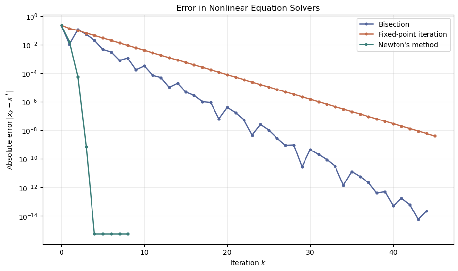

```
Method                    Iterates    Final absolute error
Bisection        45    2.276e-14
Fixed-point iteration     46    4.021e-09
Newton's method      9    5.551e-16
```

```python
colors = {
    "Bisection": "#52649a",
    "Fixed-point iteration": "#c26b4a",
    "Newton's method": "#397d78",
}

fig, ax = plt.subplots(figsize=(9.2, 5.4), constrained_layout=True)
for name, values in errors.items():
    ax.semilogy(
        np.arange(len(values)),
        values,
        marker="o",
        markersize=3.5,
        linewidth=1.8,
        color=colors[name],
        label=name,
    )

ax.set(
    title="Error in Nonlinear Equation Solvers",
    xlabel="Iteration $k$",
    ylabel=r"Absolute error $|x_k-x^*|$",
)
ax.grid(True, which="both", alpha=0.22)
ax.legend()
plt.show()

print("Method                    Iterates    Final absolute error")
for name, values in errors.items():
    print(f"{name:<12} {len(values):>6d}    {values[-1]:.3e}")
```

实验**02**

### 多项式逼近：节点选择与逼近误差

Python · Jupyter

### 多项式插值：节点选择与逼近误差

在区间 $[−1, 1]$ 上逼近 Runge 函数

$$f(x)=\frac{1}{1+25x^2}.$$

使用 SciPy 的 BarycentricInterpolator，比较等距节点与 Chebyshev 节点。

```python
import numpy as np
import matplotlib.pyplot as plt
from scipy.interpolate import BarycentricInterpolator

def runge(x):
    return 1.0 / (1.0 + 25.0 * x**2)

def equidistant_nodes(degree):
    return np.linspace(-1.0, 1.0, degree + 1)

def chebyshev_nodes(degree):
    k = np.arange(degree + 1)
    return np.cos((2 * k + 1) * np.pi / (2 * (degree + 1)))

grid = np.linspace(-1.0, 1.0, 3000)
truth = runge(grid)
```

```python
degrees = [4, 8, 12, 16]
records = []

for degree in degrees:
    for node_name, node_function in [
        ("Equidistant nodes", equidistant_nodes),
        ("Chebyshev nodes", chebyshev_nodes),
    ]:
        nodes = node_function(degree)
        interpolator = BarycentricInterpolator(nodes, runge(nodes))
        approximation = interpolator(grid)
        maximum_error = np.max(np.abs(approximation - truth))
        records.append((degree, node_name, maximum_error))

print("Degree    Node type                 Maximum absolute error")
for degree, node_name, maximum_error in records:
    print(f"{degree:>4d}    {node_name:<18} {maximum_error:.4e}")
```

```
Degree    Node type                 Maximum absolute error
   4    Equidistant nodes  4.3836e-01
   4    Chebyshev nodes    4.0202e-01
   8    Equidistant nodes  1.0452e+00
   8    Chebyshev nodes    1.7084e-01
  12    Equidistant nodes  3.6634e+00
  12    Chebyshev nodes    6.9215e-02
  16    Equidistant nodes  1.4393e+01
  16    Chebyshev nodes    3.2613e-02
```

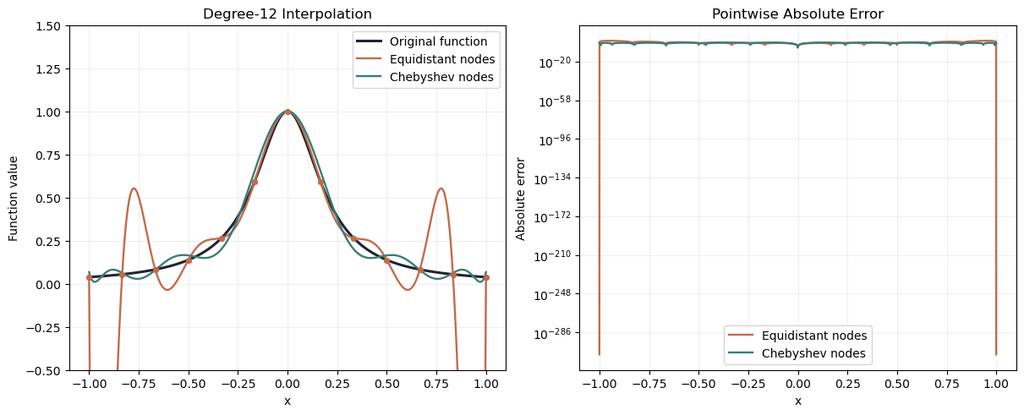

```python
degree = 12
nodes_equal = equidistant_nodes(degree)
nodes_chebyshev = chebyshev_nodes(degree)

polynomial_equal = BarycentricInterpolator(
    nodes_equal,
    runge(nodes_equal),
)(grid)
polynomial_chebyshev = BarycentricInterpolator(
    nodes_chebyshev,
    runge(nodes_chebyshev),
)(grid)

fig, axes = plt.subplots(1, 2, figsize=(12, 4.8), constrained_layout=True)

axes[0].plot(grid, truth, color="#1f2430", linewidth=2.2, label="Original function")
axes[0].plot(grid, polynomial_equal, color="#c26b4a", linewidth=1.7, label="Equidistant nodes")
axes[0].plot(grid, polynomial_chebyshev, color="#397d78", linewidth=1.7, label="Chebyshev nodes")
axes[0].scatter(nodes_equal, runge(nodes_equal), color="#c26b4a", s=18, zorder=3)
axes[0].set(
    title=f"Degree-{degree} Interpolation",
    xlabel="x",
    ylabel="Function value",
    ylim=(-0.5, 1.5),
)
axes[0].grid(alpha=0.2)
axes[0].legend()

axes[1].semilogy(
    grid,
    np.maximum(np.abs(polynomial_equal - truth), np.finfo(float).tiny),
    color="#c26b4a",
    linewidth=1.7,
    label="Equidistant nodes",
)
axes[1].semilogy(
    grid,
    np.maximum(np.abs(polynomial_chebyshev - truth), np.finfo(float).tiny),
    color="#397d78",
    linewidth=1.7,
    label="Chebyshev nodes",
)
axes[1].set(
    title="Pointwise Absolute Error",
    xlabel="x",
    ylabel="Absolute error",
)
axes[1].grid(True, which="both", alpha=0.2)
axes[1].legend()
plt.show()
```

#### 观察

提高多项式次数并不必然改善全区间逼近。等距节点在区间端点附近可能出现明显振荡；Chebyshev 节点在端点附近更密集，通常能显著降低最大误差。